# Project: Fleet Quality Analysis

- Introduction
- Research Points
- Exploratory Data Analysis
- Conclusions
- Suggested Actions

## Introduction

> **Background:** This investigation is for a food delivery application that helps people discover and order the food they will love. We have been largely focused on the food delivery and online ordering experience and our traction has been exponential. We aim to grow through a diverse set of channels while maintaining healthy economics.

**The dataset description:**

- Driver_Id: ID.
- Date: Order date.
- Pool: Delivery area.
- Delivery_Time: The duration from customer request till order arrived.
- Trip_Duration: The duration from runner acceptance till order arrived.
- Pending_to_Dispatch: The duration from dispatch the order by user till accepted by runner.
- FM: The duration from runner acceptance till arrived at restaurant.
- EFM: The estimated duration from runner acceptance till arrived at restaurant through google map.
- Waiting_Time: Waiting time in restaurant after driver arrived and before receiving order.
- LM: The duration from receiving the order from the restaurant till order arrived.
- ELM : The estimated duration from receiving the order from the restaurant till order arrived.
- Delivered: Delivery status (0 or 1).
- Total_Distance: Total distance between restaurant and customer address.
- Hour: Order hour.
- Late_FM: EFM - FM.
- Late_LM: ELM - LM.
- Total_Late: Late_FM + Late_LM.
- Lateness_status: late or not (1 or 0).

## **Research Points:**

1. Delivery duration Per pool.
2. The percentage of late trip per pool.
3. The percentage of violators with late trips per pool.
4. LM & FM Lateness Trend per Hour.
5. Correlation Between:
   - Late_LM & Total_Distance
   - Late_LM & Waiting_Time
   - Late_FM & Total_Distance
   - Late_FM & Waiting_Time .
6. Drivers Evaluation.
7. Action plan to enhance the violators % per pool.

## Exploratory Data Analysis

### Research Point 1

#### Delivery duration Per pool.

```python
# Average Delivery_Time and Trip_Duration per pool
```

| Pool | Trip_Duration | Delivery_Time |
| --- | --- | --- |
| Zayed - Palm hills | 45.976779 | 60.866300 |
| Madinaty | 43.923725 | 55.943340 |
| Haram & Faisal | 42.298519 | 55.964015 |
| Zayed - Districts | 41.533864 | 53.644261 |
| Zaytoun & Ain Shams | 40.977154 | 48.103619 |
| Alex East | 40.725214 | 51.345532 |
| Mokattam | 39.241104 | 47.491822 |
| Abbassya & Hadayek El Kobba | 38.924360 | 52.590864 |
| Maadi - Zaharaa | 38.774846 | 50.052742 |
| New Cairo - Banks | 38.352142 | 49.847172 |
| Alex West | 37.534807 | 48.835947 |
| Shoubra | 36.375435 | 51.199231 |
| Maadi - Corniche | 35.751500 | 44.422120 |
| Rehab | 35.295500 | 44.475816 |
| New Cairo - neighbourhoods | 34.626544 | 46.584832 |
| New Cairo - AUC | 34.340595 | 47.094762 |
| Nasr City | 33.985473 | 45.947027 |
| Heliopolis - Sheraton | 33.821316 | 41.758256 |
| M.D.A.Z | 33.290634 | 41.732065 |
| Heliopolis - Korba | 33.073544 | 42.216043 |
| Hadayek El Ahram | 32.321606 | 38.697376 |
| 1-Oct | 30.442134 | 37.664791 |
| El Mansoura | 26.593146 | 36.775163 |
| Tanta | 24.159175 | 35.540402 |
| Ras Sudr | 11.236640 | 22.346660 |

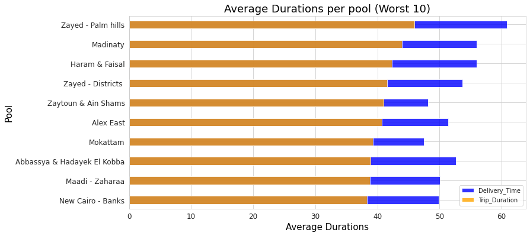

```python
# Delivery_Time and Trip_Duration per pool bar chart (Worst 10)
```

```python
# Best 5 Pools in Average Delivery_Time and Trip_Duration
```

| Pool | Trip_Duration | Delivery_Time |
| --- | --- | --- |
| Ras Sudr | 11.236640 | 22.346660 |
| Tanta | 24.159175 | 35.540402 |
| El Mansoura | 26.593146 | 36.775163 |
| 1-Oct | 30.442134 | 37.664791 |
| Hadayek El Ahram | 32.321606 | 38.697376 |

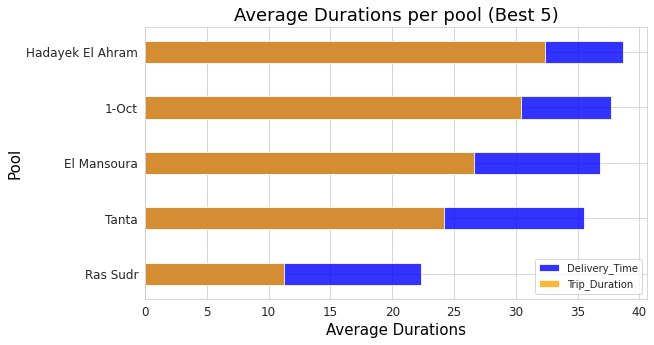

```python
# Delivery_Time and Trip_Duration per pool bar chart (Best 5)
```

### Result 1:

```
- Zayed - Palm hills.
- Madinaty
- Haram & Faisal
- Zayed - Districts
- Zaytoun & Ain Shams
- Alex East
- Mokattam
- Abbassya & Hadayek El Kobba
- Maadi - Zaharaa
- New Cairo - Banks
```

**2. The best five pools in both average Trip_Duration and average Delivery_time are:**

```
- Hadayek El Ahram.
- 1-Oct
- El Mansoura
- Tanta
- Ras Sudr
```

**3. The Pending_to_Dispatch average time is the highest in:**

```
- Zayed - Palm hills (14.89) min on average
- Haram & Faisal (14:88) min on average (13.67)min on average
- Abbassya & Hadayek El Kobba.(13.67) min on average
```

### Research Point 2

#### The percentage of late trip per pool.

```python
# Lateness percentage per pool LM of FM
```

```
Pool
Tanta                          17.688266
El Mansoura                    33.275261
New Cairo - AUC                36.931818
1-Oct                          38.356164
Nasr City                      47.188049
Abbassya & Hadayek El Kobba    48.623853
Ras Sudr                       50.000000
M.D.A.Z                        50.120337
New Cairo - neighbourhoods     51.967213
Zayed - Districts              54.005525
Heliopolis - Sheraton          56.470588
Madinaty                       57.754011
Rehab                          57.809695
Maadi - Corniche               57.883050
Heliopolis - Korba             59.926918
Zaytoun & Ain Shams            60.126582
Alex West                      60.990338
New Cairo - Banks              61.633663
Maadi - Zaharaa                61.666667
Shoubra                        62.566845
Hadayek El Ahram               63.963964
Haram & Faisal                 64.062500
Mokattam                       65.497076
Zayed - Palm hills             65.562914
Alex East                      68.664850
Name: Lateness_status, dtype: float64
```

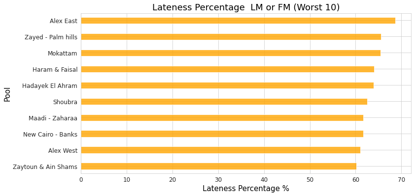

```python
# Lateness Percentage per pool bar plot
```

### Result 2:

**1. The worst ten pools on Lateness Percentage are:**

[output not shown]

### Research Point 3

#### The percentage of violators with late trips per pool.

```python
#  Violators Lateness Percentage per pool
```

| Pool | Total_Drivers | Violators_Drivers | Violators_Percentage |
| --- | --- | --- | --- |
| Alex East | 365 | 252 | 69.041096 |
| Zayed - Palm hills | 300 | 198 | 66.000000 |
| Mokattam | 170 | 112 | 65.882353 |
| Hadayek El Ahram | 220 | 142 | 64.545455 |
| Shoubra | 182 | 117 | 64.285714 |
| Haram & Faisal | 383 | 246 | 64.229765 |
| Maadi - Zaharaa | 1128 | 703 | 62.322695 |
| New Cairo - Banks | 400 | 249 | 62.250000 |
| Alex West | 823 | 505 | 61.360875 |
| Zaytoun & Ain Shams | 155 | 95 | 61.290323 |
| Heliopolis - Korba | 820 | 492 | 60.000000 |
| Maadi - Corniche | 1343 | 782 | 58.227848 |
| Madinaty | 559 | 324 | 57.960644 |
| Rehab | 556 | 322 | 57.913669 |
| Heliopolis - Sheraton | 1184 | 672 | 56.756757 |
| Zayed - Districts | 721 | 391 | 54.230236 |
| New Cairo - neighbourhoods | 606 | 317 | 52.310231 |
| M.D.A.Z | 1656 | 833 | 50.301932 |
| Ras Sudr | 6 | 3 | 50.000000 |
| Abbassya & Hadayek El Kobba | 109 | 53 | 48.623853 |
| Nasr City | 2263 | 1074 | 47.459125 |
| 1-Oct | 652 | 252 | 38.650307 |
| New Cairo - AUC | 696 | 260 | 37.356322 |
| El Mansoura | 1136 | 382 | 33.626761 |
| Tanta | 567 | 101 | 17.813051 |

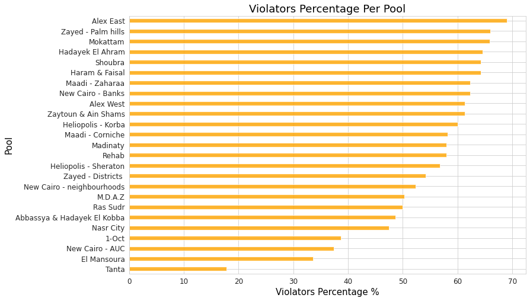

```python
# Violators Lateness Percentage per pool bar plot
```

### Result 3:

**1. The worst ten pools on Violators percentage in FM or LM are:**

```
- Alex East             69.04 %
- Zayed - Palm hills    66.00 %
- Mokattam              65.88 %
- Hadayek El Ahram    64.55 %
- Shoubra           64.29 %
- Haram & Faisal        64.23%
- Maadi - Zaharaa      62.32%
- New Cairo - Banks  62.25%
- Alex West          61.36%
- Zaytoun & Ain Shams   61.29%




    -
```

### Research Point 4

#### LM & FM Lateness Trend per Hour

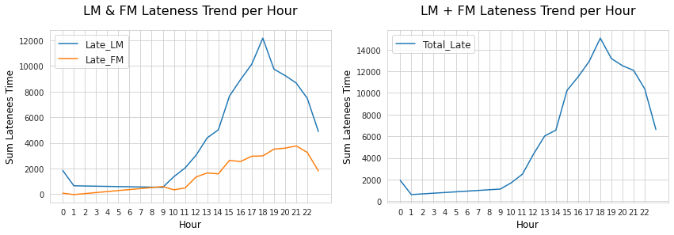

```python
# LM & FM Lateness Trend per Hour line trend per hour
                                                        # LM + FM Lateness Trend per Hour line trend per hour
```

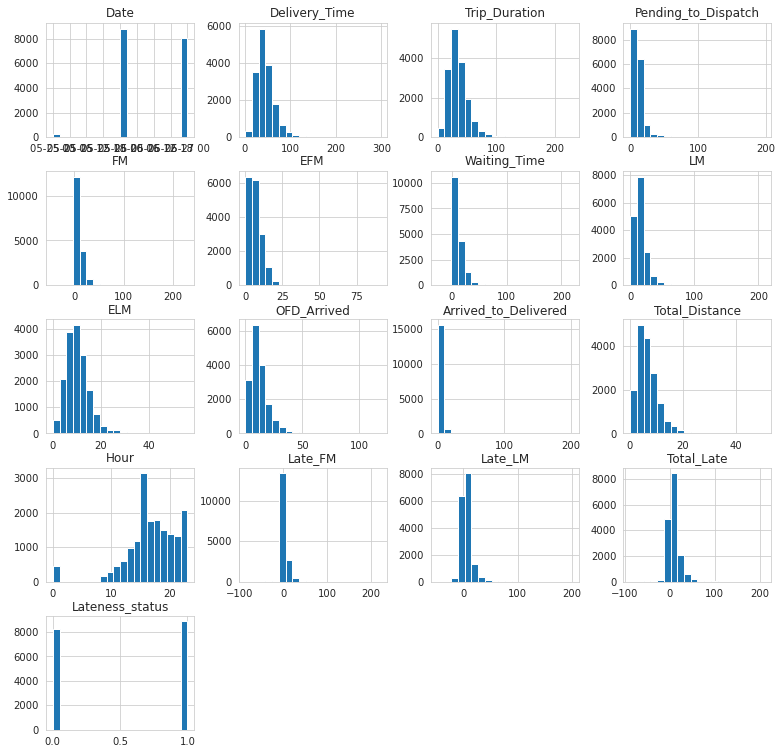

```python
# Check distribution of variables
```

### Result 4:

**From above visualizations we can see that:**

```
- The highest LM Lateness at 18:00 O'clock.
- The highest FM Lateness at 21:00 O'clock.
- Total Lateness of LM + FM is the highest at 18 O'clock.
```

**So we need to pay more effort on hours between 18 and 21 to decrease Lateness time like raise EFM and ELM time a little**

### Research Point 5

#### Correlation Between Late_LM and Total_Distance.

#### Correlation Between Late_LM and Waiting_Time.

#### Correlation Between Late_FM and Total_Distance.

#### Correlation Between Late_FM and Waiting_Time .

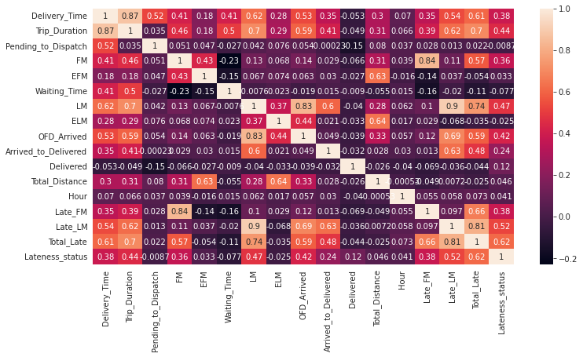

```python
# Check correlation map
```

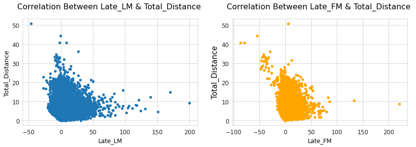

```python
# Scatter plot Late_LM vs Total_Distance
                                            # Scatter plot Late_FM vs Total_Distance
```

[figure not shown]

```python
# Scatter plot Late_LM vs Waiting_Time
                                            # Scatter plot Late_FM vs Waiting_Time
```

### Result 5:

**From above visualizations we can see that:**

```
- There is no correlation between Waiting_Time and Late_LM.
- There is no correlation between Waiting_Time and Late_FM.
- There is no correlation between Total_Distance and Late_LM.
- There is no correlation between Total_Distance and Late_FM.
```

### Research Point 6

#### Drivers Evaluation

```python
# Drivers with Lateness percentage between 70% and 90 % which made more than 10 orders
```

|  | Pool | Driver_Id | Lateness_Percentage | Orders_Count | Total_Late |
| --- | --- | --- | --- | --- | --- |
| 4 | Alex East | 0c2f3af2-6b78-400b-9f28-a1d5b6076132 | 86.666667 | 15 | 334.816433 |
| 18 | Alex West | ad95df21-a01c-49ef-b58c-2a056c07c206 | 83.333333 | 12 | 133.516867 |
| 16 | Alex West | 99b149c9-7934-46c5-bfbb-caa3e54ff8b5 | 83.333333 | 22 | 312.299867 |
| 15 | Alex West | 7d9467d4-5a2c-46e3-8820-ae51ec7b1ee6 | 83.333333 | 18 | 278.850033 |
| 11 | Alex West | 47321a43-9a50-452f-8d0a-1696020abdd7 | 81.250000 | 16 | 164.066567 |
| 10 | Alex West | 3569dbf4-8c1e-423e-81e8-4f653b1b0424 | 80.000000 | 20 | 143.716767 |
| 9 | Alex West | 33693d7a-0ba7-4e46-8db1-aaaf531ac120 | 80.000000 | 20 | 304.949767 |
| 12 | Alex West | 5b1c7cbf-3d42-4382-978c-50221e33c68e | 80.000000 | 15 | 190.433267 |
| 7 | Alex East | a83ce027-cc9d-456b-80ec-45976d662bfb | 79.310345 | 28 | 361.499633 |
| 19 | Alex West | bd0e956e-4451-48e3-ac12-abdeef470792 | 79.166667 | 24 | 331.850500 |
| 3 | Alex East | 01e80b89-97c2-4548-91cd-56cac616741c | 78.947368 | 19 | 202.083500 |
| 14 | Alex West | 76737f90-b42a-401b-9238-47bcfb06514d | 78.571429 | 14 | 78.099900 |
| 8 | Alex West | 0f982390-805d-49f9-acac-5d72d81a27e0 | 77.777778 | 18 | 188.666567 |
| 17 | Alex West | a5972561-0171-487d-9b06-d5e312a150fc | 76.470588 | 17 | 230.650100 |
| 0 | 1-Oct | 863dc372-dafa-4963-9b31-beb91ae8117c | 73.684211 | 19 | 169.449667 |
| 1 | 1-Oct | f251f7dd-fb8a-4677-b883-08f39433baec | 73.076923 | 25 | 414.883600 |
| 6 | Alex East | a6dd12c5-a21c-4a7c-973f-661163d23e77 | 72.000000 | 24 | 207.316467 |
| 13 | Alex West | 63e24b7f-570d-407b-9e5b-dc54b92b1e78 | 71.428571 | 21 | 255.700033 |
| 2 | Abbassya & Hadayek El Kobba | d803b728-2212-40d5-b467-082bdf777d82 | 71.428571 | 13 | 153.083100 |
| 5 | Alex East | 4b722ea5-3056-49fd-82ce-108821c5bcc4 | 70.967742 | 30 | 306.483233 |

```python
# Drivers with Lateness percentage more than 90 % which made more than 10 orders
```

|  | Pool | Driver_Id | Lateness_Percentage | Orders_Count | Total_Late |
| --- | --- | --- | --- | --- | --- |
| 19 | Madinaty | 62b2815a-82e6-4707-9b38-78bf196661ee | 100.000000 | 18 | 356.133467 |
| 18 | Maadi - Zaharaa | 4fdba9c8-ad22-4cc3-a560-63b5d71d46cb | 100.000000 | 15 | 304.883433 |
| 4 | Haram & Faisal | 8e914b9b-d1e1-4c00-9c1f-a6dd524754d2 | 100.000000 | 12 | 193.283267 |
| 17 | Maadi - Zaharaa | 481acb7d-16c4-4cfa-ba1f-cedec72b926b | 100.000000 | 17 | 260.600067 |
| 6 | Heliopolis - Korba | 5963ef33-bbaa-4af5-9d06-610a8b70d596 | 100.000000 | 14 | 291.133000 |
| 16 | Maadi - Corniche | bb1556e8-0840-421d-8d5a-9c6651b7a26d | 100.000000 | 18 | 327.766533 |
| 9 | M.D.A.Z | 146f58b1-c9c2-4c65-86ec-2a87ec4e966c | 100.000000 | 12 | 318.883400 |
| 15 | Maadi - Corniche | 9a43924f-a112-48fe-8dbe-b6b584b02704 | 100.000000 | 11 | 260.566467 |
| 12 | M.D.A.Z | a1723122-4551-4d5f-a3ba-7087b0f181ec | 95.000000 | 20 | 359.799567 |
| 8 | Heliopolis - Sheraton | 23a923f9-17a6-48d5-aa6f-2375634a50f4 | 94.117647 | 17 | 210.966833 |
| 3 | Haram & Faisal | 8e826a72-45b8-4e4a-b73b-3885ed262ead | 92.857143 | 14 | 255.032967 |
| 1 | Alex East | edbae21d-88aa-49f2-95de-f7f2695bbf1d | 92.857143 | 14 | 245.883533 |
| 13 | Maadi - Corniche | 3509178a-f779-4a67-bd4b-52995921ee6d | 92.307692 | 13 | 319.350200 |
| 10 | M.D.A.Z | 857a000f-f8f9-445f-a526-c063df8d58c0 | 92.307692 | 13 | 249.916600 |
| 5 | Heliopolis - Korba | 1330d48c-6627-469a-b78e-46eafd66d0fd | 92.307692 | 13 | 225.466867 |
| 2 | Alex West | bca56461-5bef-4446-ac2f-17a72f89bd71 | 92.307692 | 13 | 183.533400 |
| 14 | Maadi - Corniche | 4a3ca91e-312c-4ae7-9b1c-312c23349994 | 90.909091 | 11 | 153.899967 |
| 7 | Heliopolis - Korba | b4b4ce7d-2d22-4063-801e-2c7affda4b03 | 90.909091 | 11 | 191.450100 |
| 0 | Alex East | a808fc36-0f0a-4e75-9bfd-3417591ce560 | 90.909091 | 11 | 147.783067 |
| 11 | M.D.A.Z | 9b0b6210-960c-4b1c-8e7e-e2e9b4acaab5 | 90.476190 | 21 | 209.266500 |

## Drivers data attached into two sheets

### Result 6:

**I divided drivers data into 2 different sheets:**

> ```
> 1. Drivers_need_coaching sheet includes Drivers who have Lateness_Percentage between 70% and 90% and Orders Counts more than 10.
>
> 2. Drivers_need_actions sheet includes Drivers who have Lateness_Percentage more than 90 % and order counts more than 10.
> ```

**From all previous data and visualization we statistically suggest these actions:**

> ```
> - Observe the first group, make fast meetings with them and try to find the reason behind the high lateness percentage from total orders they delivered.
>
> - Observe the second group as well and take the necessary actions with them.
> ```

## Conclusions

**1. The highest average for Trip_Duration and Delivery_time is in:**

```
 - Zayed - Palm hills
 - Madinaty
 - Haram & Faisal Pools have
```

**2. The Pending_to_Dispatch average time is the highest in:**

```
- Zayed - Palm hills (14.89) min.
- Haram & Faisal (14:88) min on average (13.67) min.
- Abbassya & Hadayek El Kobba.(13.67) min.
```

**3. The worst pools on Lateness Percentage are:**

```
- Alex East                      68.66 % Lateness   (Late_LM or Late_FM more than or equal to 5 Minutes)
- Zayed - Palm hills             65.56 % Lateness
- Mokattam                       65.50 % Lateness
```

**4. Alex East, Zayed - Palm hills and Mokattam Pools have the highest Violators percentage in LM or FM with 69%, 66% and 65.88 respectively.**

**5. We need to pay more effort on hours between 18:00 and 21:00 O'clock to decrease Lateness time:**

```
- The highest LM Lateness value at 18:00 O'clock.
- The highest FM Lateness value at 21:00 O'clock.
- Total Lateness of LM + FM is the highest at 18 O'clock.
```

**6. There are no correlations that affect Lateness time in this dataset.**

## Suggested Actions

**1. - Every Pool manager should observe Drivers with Lateness Percentage between 70% and 90%, make fast meeting with them and try to find the reason behind high lateness percentage from total orders they delivered.**

**2. - Observe Drivers with Lateness Percentage more than 90% as well you may find another issues with their performance. Take the necessary actions with them**

**3. Collect more data about drivers to analyze their behaviour and find out the reasons behind high lateness percentage to avoid in the future**

**4.Pay more effort on hours between 18:00 O'clock and 21:00 O'clock:**

```
 - Raise EFM and ELM time a little to avoid lateness.
 - Manage breaks to not intersect with this period.
```

## Limitations

**1. There is a lot of empty values in each columns specially columns that indicates lateness which may affect our analysis accuracy.**

**3.Finally to evaluate Drivers performance effectively we need more data about them like their behavior and working hours and customer rating.**